# Analysing Credit Data: Focus on Risky Loans

Sylvester

2022-06-30

## Introduction

As part of the services of some financial institutions providing credit for customers and businesses is accompanied by many challenges like defaults in payments. Hence, there is a need for these financial institutions to mitigate the challenges.

I will be applying my skills in **data analysis**, especially in the **descriptive**, **prescriptive** and **predictive** aspects to find insights and patterns from the credit data set to help solve this problem for the financial institutions.

## Objective

The agenda is to predict possible credit defaulters up front and help the financial institutions to take steps accordingly.

## My Approach

I will explore the data to find out why customers default on loan payments. I will further make conclusions and recommendations based on the exploratory analysis findings.

### Exploratory Analysis

In this section, I will be focusing on risky loans and non-risky loans as defined by the source of the data set. I will explore the features and patterns associated with defaulted loans.

```
##                                                   Var1   Freq     Avg
## 1                                          Charged Off  45248 0.05099
## 2                                              Current 601779 0.67815
## 3                                              Default   1219 0.00137
## 4  Does not meet the credit policy. Status:Charged Off    761 0.00086
## 5   Does not meet the credit policy. Status:Fully Paid   1988 0.00224
## 6                                           Fully Paid 207723 0.23409
## 7                                      In Grace Period   6253 0.00705
## 8                                               Issued   8460 0.00953
## 9                                    Late (16-30 days)   2357 0.00266
## 10                                  Late (31-120 days)  11591 0.01306
```

*Comment*

*Risky loans comprise 5.322% of loans a total of 47,228 single loans. Where as, non risky loans comprise 94.678% of loans a total of 840,151 single loans.*

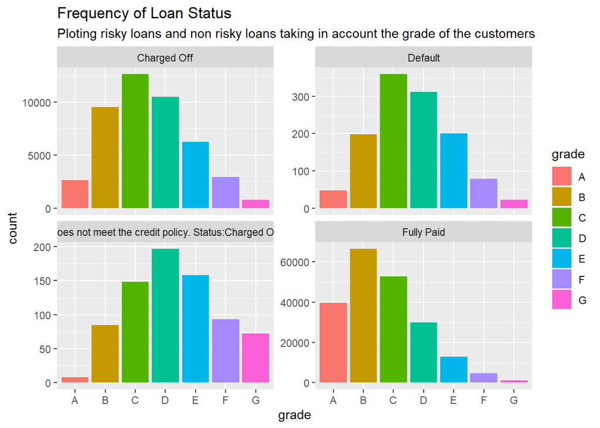

Figure 1

*Comment*

*Loan grades are allocated to loans based on the customer’s past credit history. Lower performance has lower grades and vice versa. Grades B, C, and D make up more than 70% of Charged off loans. A similar situation is with defaulted loans. The condition becomes worse when no policy meets loans.*

*The Fully Paid facet in figure 1 and compared with other graphs in figure 1, shows a clear pattern that as the loan grade goes from A to G the Risk increases as well.*

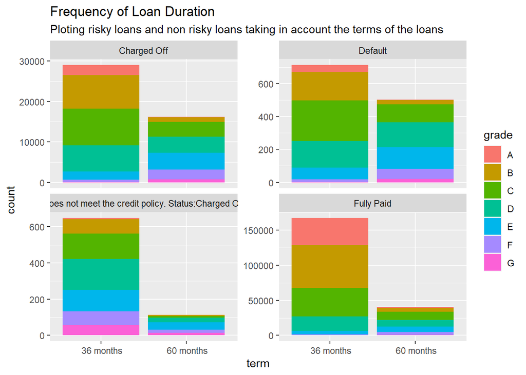

Figure 3

*Comment*

*Customers prefer short term loans.*

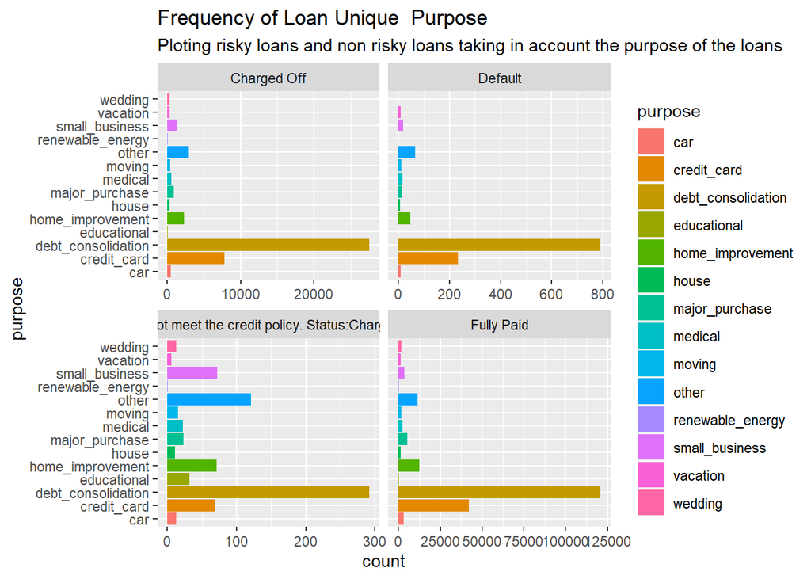

Figure 2

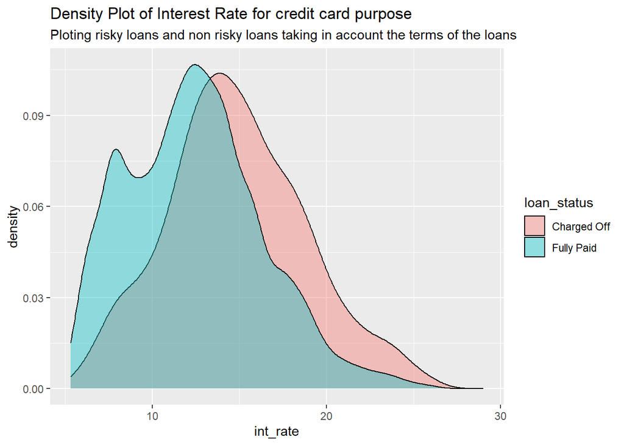

Figure 4

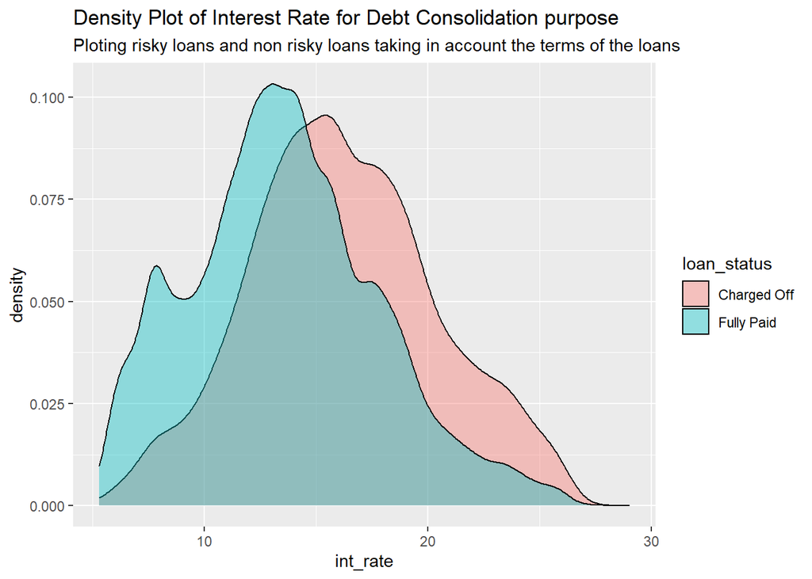

Figure 5

*Comment*

*Debt consolidation and credit card are consistently high in all facets of the loan terms.*

*Debt consolidation refers to the act of taking out a new loan to pay off other liabilities and consumer debts. Interest rate for Fully Paid looks a little left skewed than charged of loans*

### Report

Also, customers generally prefer short term loans than long term loans. There is also a high incidence of loans used for the purpose of debt and credit card consolidation. This shows clearly that, borrowers already have ongoing loans, then they desperately take loans even at high interest rates to clear other ongoing loans at different financial institutions.

Debt consolidation loans are taken when one is unable to pay for an ongoing loan, hence acquiring these types of loans at high interest rates becomes a hassle to repay.